# Getting Started: Diamonds

Angela Sharer 2020-07-11

- Grading Rubric
  - Individual
  - Team
  - Due Date
- Data Exploration
- Communication

*Purpose*: Throughout this course, you’ll complete a large number of *exercises* and *challenges*. Exercises are meant to introduce content with easy-to-solve problems, while challenges are meant to make you think more deeply about and apply the content. The challenges will start out highly-scaffolded, and become progressively open-ended.

In this challenge, you will go through the process of exploring, documenting, and sharing an analysis of a dataset. We will use these skills again and again in each challenge.

# Grading Rubric

Unlike exercises, **challenges will be graded**. The following rubrics define how you will be graded, both on an individual and team basis.

## Individual

| Category | Unsatisfactory | Satisfactory |
| --- | --- | --- |
| Effort | Some task **q**’s left unattempted | All task **q**’s attempted |
| Observed | Did not document observations | Documented observations based on analysis |
| Supported | Some observations not supported by analysis | All observations supported by analysis (table, graph, etc.) |
| Code Styled | Violations of the [style guide](https://style.tidyverse.org/) hinder readability | Code sufficiently close to the [style guide](https://style.tidyverse.org/) |

## Team

| Category | Unsatisfactory | Satisfactory |
| --- | --- | --- |
| Documented | No team contributions to Wiki | Team contributed to Wiki |
| Referenced | No team references in Wiki | At least one reference in Wiki to member report(s) |
| Relevant | References unrelated to assertion, or difficult to find related analysis based on reference text | Reference text clearly points to relevant analysis |

## Due Date

All the deliverables stated in the rubrics above are due on the day of the class discussion of that exercise. See the [Syllabus](https://docs.google.com/document/d/1jJTh2DH8nVJd2eyMMoyNGroReo0BKcJrz1eONi3rPSc/edit?usp=sharing) for more information.

```r
library(tidyverse)
```

# Data Exploration

In this first stage, you will explore the `diamonds` dataset and document your observations.

**q1** Create a plot of `price` vs `carat` of the `diamonds` dataset below. Document your observations from the visual.

*Hint*: We learned how to do this in `e-vis00-basics`!

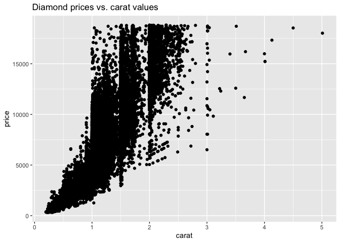

```r
## TASK: Plot `price` vs `carat` below

ggplot(diamonds) +
  geom_point(mapping = aes(x = carat, y = price)) +
  labs(title = "Diamond prices vs. carat values")
```

**Observations**:

- As one might expect, a higher carat value means, roughly, that the price of the diamond will be higher, but with variation due (probably) to those other “C” variables: clarity, color, and cut.
- There is some interesting clustering happening though, with a lot more diamonds falling right above 2 carats than right below, it seems. When I did the first exercise, I wrote, “This makes me wonder how carats work, OR if there is something about this dataset that would have selected for these differently…” But now that I have read the Wikipedia bit about “carat over cut,” I see that there is a lot more human intervention in determining the carat value than I would have otherwise guessed. For whatever reason (ease of filtering? A human tendency to discount fractional values like 1.1 as “basically 1”–and thus not worth an increased price over a 1 carat diamond?), it seems that the people who cut diamonds are optimizing for carat values of 1, 1.5, 2, etc.–or very close to those values, anyway.
- There seems to be some clipping happening with the price, as well–I would guess this dataset pulled a set of diamonds under a particular price point, or a set of diamonds starting with the least expensive and ending at a certain number of diamonds (53,940?). I know they can cost more than $20k in the real world…

**q2** Create a visualization showing variables `carat`, `price`, and `cut` simultaneously. Experiment with which variable you assign to which aesthetic (`x`, `y`, etc.) to find an effective visual.

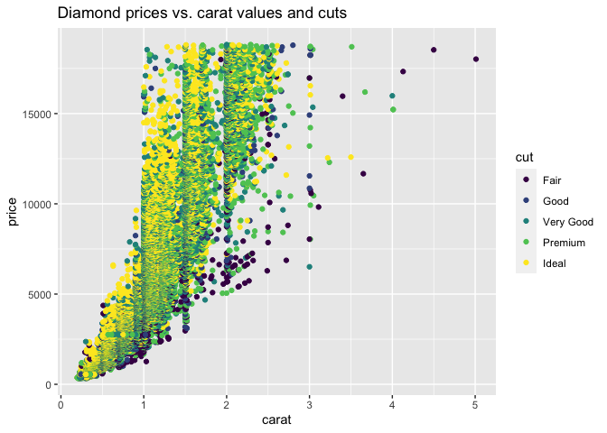

```r
## TASK: Plot `price`, `carat`, and `cut` below

ggplot(diamonds) +
  geom_point(mapping = aes(x = carat, y = price, color = cut)) +
  labs(title = "Diamond prices vs. carat values and cuts")
```

```r
#ggplot(diamonds) +
#  geom_boxplot(mapping = aes(x = cut, y = carat))
```

**Observations**:

Before I learned about the way carats are prioritized, I wrote the following:

- Obviously cut also has a relationship to price–the better the cut (for a given carat value), generally the higher the price.
- But, there are a lot of points (it seems) that do not clearly fit this pattern…

But now,

- It does seem that Ideal cuts are more concentrated in the lower-carat diamonds, and poorer quality cuts dominate the higher-carat diamonds.

Additionally, I have questions!

**First, am I correct that there is clustering around integer carat values, and around 1.5 carats?**

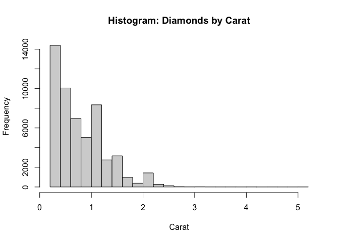

```r
carat_vector <- diamonds$carat
hist(x = carat_vector, main = "Histogram: Diamonds by Carat",  xlab="Carat", breaks = 20)
```

**Observations**:

**Are there other clusters in the lower-carat value diamonds?**

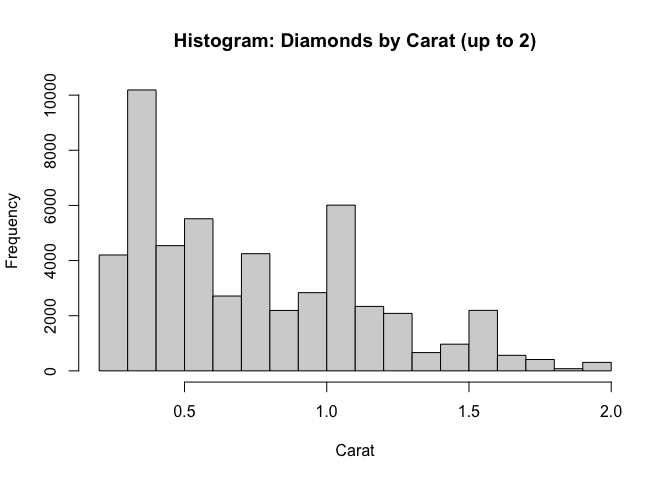

```r
diamonds_up_to_2 <- filter(diamonds, carat <= 2)
carat_vector_up_to_2 <- diamonds_up_to_2$carat
hist(x = carat_vector_up_to_2, main = "Histogram: Diamonds by Carat (up to 2)",  xlab="Carat",  breaks = 24)
```

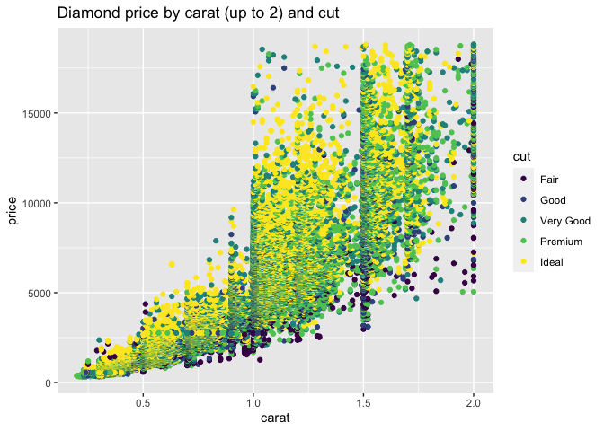

```r
ggplot(diamonds_up_to_2) +
  geom_point(mapping = aes(x = carat, y = price, color = cut)) +
  labs(title = "Diamond price by carat (up to 2) and cut")
```

**Observations**:

- Yes, I think I am seeing multiple clusters when I look more closely at the lower-carat value diamonds. There is very clearly one around 0.3 carats (I wonder if this is a good carat weight for e.g. pave diamonds?), probably one around 0.5 carats, and another at 0.7 carats (or so; I’m not being terribly precise here).
- The shape of this histogram is not what I would have guessed before I learned about how the carat value of a diamond is determined. (I would have expected a normal distribution, I think, not all these spikes.)

**Next, what’s happening above 2 carats?**

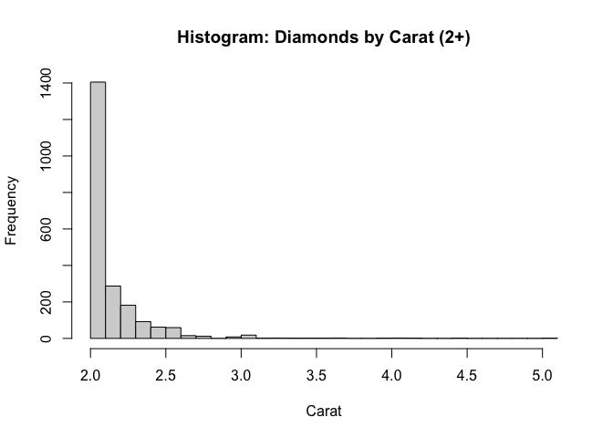

```r
diamonds_2plus <- filter(diamonds, carat >= 2)
carat_vector_2plus <- diamonds_2plus$carat
hist(x = carat_vector_2plus, main = "Histogram: Diamonds by Carat (2+)",  xlab="Carat",  breaks = 24)
```

There are not many diamonds with a carat value higher than 3 in this dataset. Let’s set those aside and focus on the 2-3 carat diamonds.

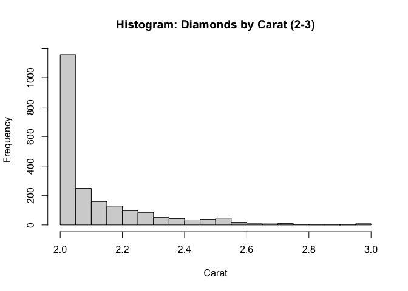

```r
diamonds_2_to_3 <- filter(diamonds, carat >= 2 & carat <= 3)
carat_vector_2_to_3 <- diamonds_2_to_3$carat
hist(x = carat_vector_2_to_3, main = "Histogram: Diamonds by Carat (2-3)",  xlab="Carat", breaks = 20)
```

**Observations**:

- In my histogram, I see the cluster of diamonds at 2 carats, and it looks like I do have a smallish cluster at 2.5, but this is so subtle as to perhaps be noise–the trend seems stronger in the 1-2 carat diamonds. Hypothesis: Above 2 carats, you might as well go up to 3, psychologically speaking? But when you’re in the normal-people range of less than 2 carats, 1.5 is a substantial jump from 1, and thus feels more worthwhile…?

**But what about cut? If I filter the dataset by cut, do other patterns emerge?**

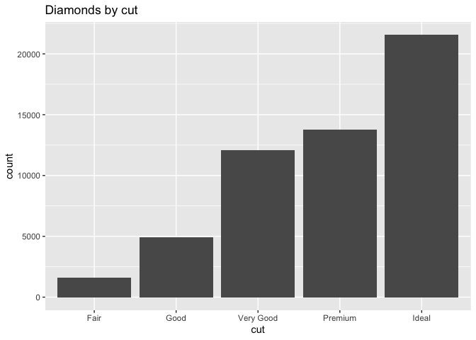

```r
ggplot(diamonds) +
  geom_bar(mapping = aes(cut)) +
  labs(title = "Diamonds by cut")
```

**Observations**:

- The number of diamonds of each cut increases with the cut’s quality; there are few Fair cut diamonds in the set compared to the number of Ideal cut diamonds.

**How do the price vs. carat distributions vary by cut?**

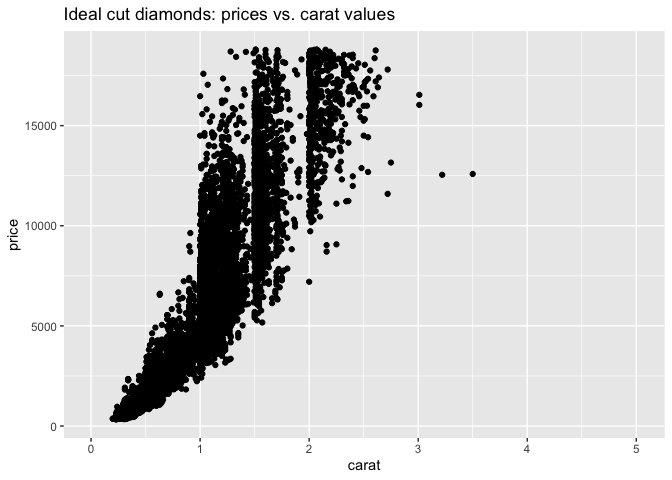

```r
ideal_diamonds <- filter(diamonds, cut == "Ideal")
ggplot(ideal_diamonds) +
  geom_point(mapping = aes(x = carat, y = price)) +
  labs(title = "Ideal cut diamonds: prices vs. carat values") +
  xlim(0,5.01)
```

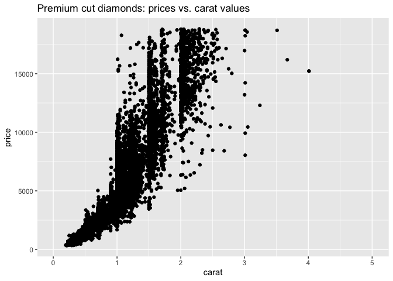

```r
premium_diamonds <- filter(diamonds, cut == "Premium")
ggplot(premium_diamonds) +
  geom_point(mapping = aes(x = carat, y = price)) +
  labs(title = "Premium cut diamonds: prices vs. carat values") +
  xlim(0,5.01)
```

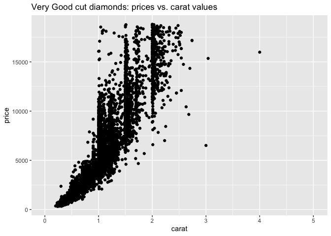

```r
vgood_diamonds <- filter(diamonds, cut == "Very Good")
ggplot(vgood_diamonds) +
  geom_point(mapping = aes(x = carat, y = price)) +
  labs(title = "Very Good cut diamonds: prices vs. carat values") +
  xlim(0,5.01)
```

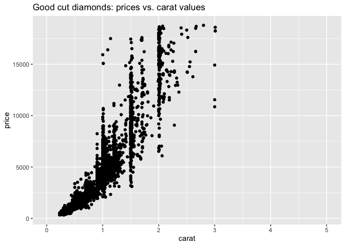

```r
good_diamonds <- filter(diamonds, cut == "Good")
ggplot(good_diamonds) +
  geom_point(mapping = aes(x = carat, y = price)) +
  labs(title = "Good cut diamonds: prices vs. carat values") +
  xlim(0,5.01)
```

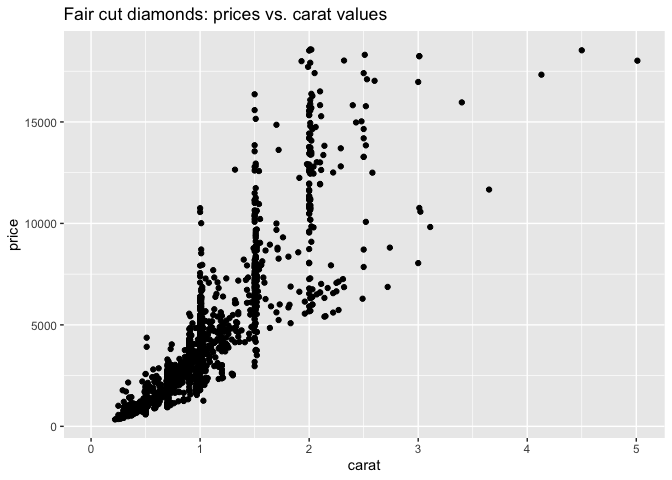

```r
fair_diamonds <- filter(diamonds, cut == "Fair")
ggplot(fair_diamonds) +
  geom_point(mapping = aes(x = carat, y = price)) +
  labs(title = "Fair cut diamonds: prices vs. carat values") +
  xlim(0,5.01)
```

**Observations**:

- These plots do end up looking quite different from one another, due in part to the differences in sample size.
- Diamonds of all cuts can achieve a high price, but the poorer-quality cuts must achieve a much higher carat rating than the higher-quality cuts to do so.
- All cuts seem to exhibit the same clustering around certain “friendly” carat values, though further examination would be needed to see if the clusters were consistent from cut to cut below a single carat (it’s difficult to tell in these scatterplots; that area of the plot becomes quite dense).

# Communication

In this next stage, you will render your data exploration, push it to GitHub to share with others, and link your observations within our [Data Science Wiki](https://olin-data-science.fandom.com/wiki/Olin_Data_Science_Wiki).

**q3** *Knit* your document in order to create a report.

You can do this by clicking the “Knit” button at the top of your document in RStudio.

[figure not shown]

Terminal

This will create a local `.md` file, and RStudio will automatically open a preview window so you can view your knitted document.

**q4** *Push* your knitted document to GitHub.

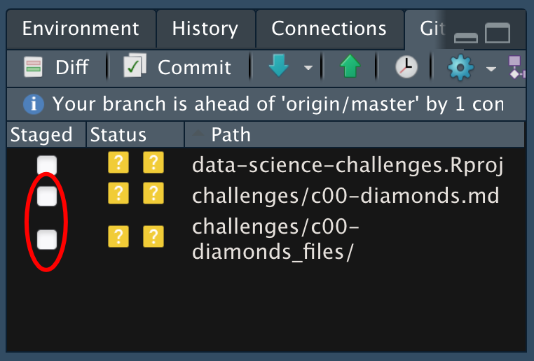

Terminal

You will need to stage both the `.md` file, as well as the `_files` folder. Note that the `_files` folder, when staged, will expand to include all the files under that directory.

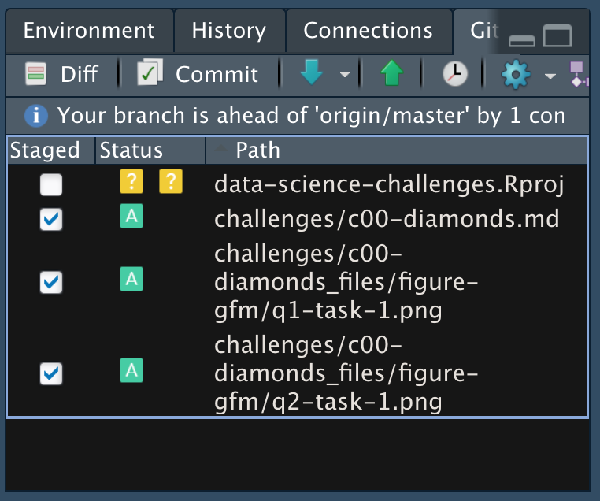

Terminal

**q5** *Document* your findings in our Wiki. Work with your learning team to come to consensus on your findings.

The Datasets page contains lists all the datasets we’ve analyzed together.

**q6** *Prepare* to present your team’s findings!

**q7** Add a link to your personal data-science repository on the Repositories page. Make sure to file it under your team name!